# R/Rstudio入門

Quartoを使って解析・論文執筆しよう！

国里愛彦

# 統計解析環境の構築

# RとRStudioを使います

## SPSSではダメな理由

- 以下の理由からSPSSは，すすめない
1. SPSSでは，できない解析がある
2. 機能のわりに高価（卒業後は使えない）
3. 操作マニュアルは多いが，教育上は悪い影響も（統計学を理解せずに解析するなど）
4. データの整形機能が貧弱
5. 解析過程が残らない（解析が再現出来ない可能性がある）
6. 出力が非常に見にくい（好みの問題ですが・・・）

## Excelではダメな理由

- SPSSでデータ整形は難しいので，Excelで前処理をすることも多いのでは？
- しかし，以下の理由から，Excelもすすめない。
1. 操作の過程が残らない（Excelで行った操作を別のファイルに記録しないと再現不可能になる）
2. 生データ自体が改変される
3. 本格的な統計解析・可視化は難しい（HADという選択もあるが・・・）

## RとRStuidoを薦める理由

- RとRstudioならSPSSやExcelの問題は，以下のようにクリアできます。
1. できない統計解析はほとんどない
2. 解析過程がしっかり残る
3. データの整形，可視化，解析，解析レポート作成（マニアは論文やプレゼンも）可能
4. こんなにすごいのに，無料！
5. 学生が統計を学習する上で便利（自宅でもできる＆修了後も使える）

## Rのインストール

[The R Project for Statistical Computing](https://www.r-project.org/)にアクセスし，「download R」をクリックする。

[figure not shown]

- ミラーサイトを選ぶ(0-CloudかJapanのどれかを選ぶ)

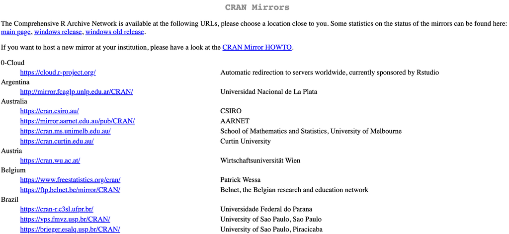

- 使っているOSを選択する

## Windowsユーザーの場合

- 「Download R for Windows」をクリックする。
- 「base」をクリックする

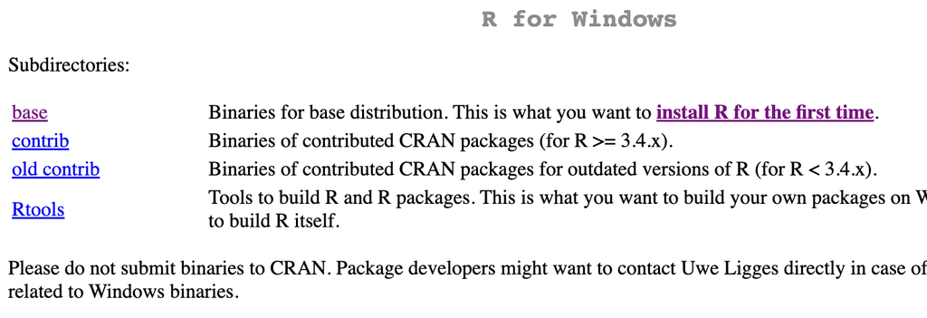

- 「Download R-XX for Windows」（xxはバージョン名）をクリックしてダウンロード＆インストールする。

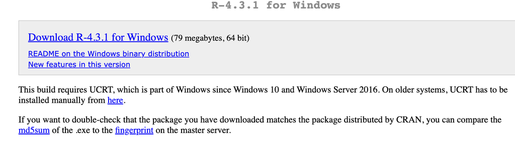

**Rtoolsのインストール**

- さきほど「base」をクリックしたところで「Rtools」を選択する。

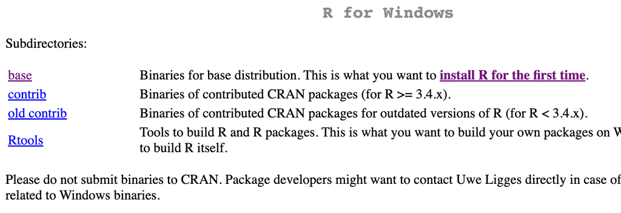

- さきほどインストールしたRのバージョンと同じバージョンのRtoolsをクリックする。

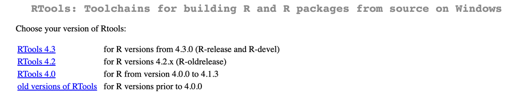

- 「RtoolsXX installer」(XXはバージョン)をクリックして，ダウンロード＆インストールする。

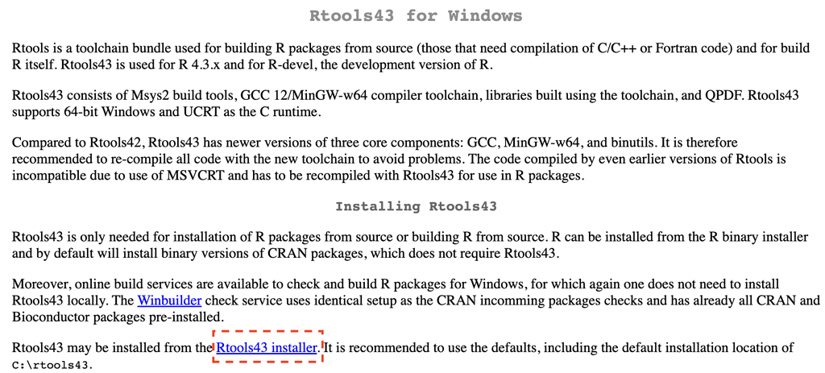

**Windowsユーザーの注意事項**

ユーザー名を日本語名にしていると問題が発生することがある。英語名のユーザーを追加するか，[こちら](https://www.jaysong.net/RBook/installation.html#step-3-%E3%83%A6%E3%83%BC%E3%82%B6%E3%83%BC%E5%90%8D%E3%82%92%E7%A2%BA%E8%AA%8D%E3%81%99%E3%82%8B)を参考にして，設定を変更する。

## Macユーザーの場合

**Xcodeのインストール**

- まず，「Xcode」をインストールする。App Storeを起動して，「Xcode」で検索して，「入手」する（「開く」になっている場合は，インストール済みである）。インストールには時間かかる。

**コマンドラインツールのインストール**

- インストール後に以下をターミナルで実行する。

```
xcode-select --install
```

**Xquartzのインストール**

- [Xquartz](https://www.xquartz.org/)にアクセスし，ダウンロード＆インストールする。

[figure not shown]

**Rのインストール**

- 「Download R for mac OS」をクリックする。
- Macの種類に合わせてクリックして，ダウンロード＆インストールする。Apple siliconの場合はarm64版をインストールし，Intel Macの場合はx86_64版をインストールする。

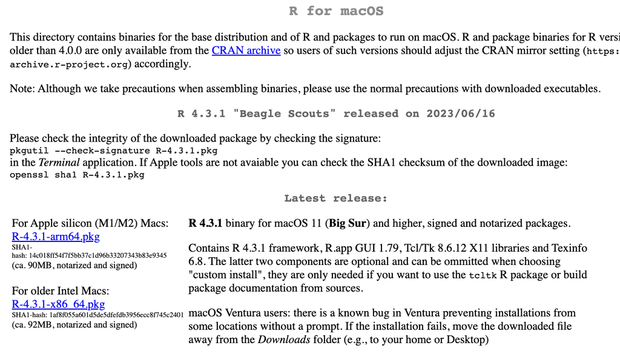

## RStuidoのインストール

- [posit](https://posit.co/)社のサイトにアクセスして，「DOWNLOAD RSTUDIO」をクリックする。

[figure not shown]

- 移動した先のサイトで下にスクロールして，Free版の「RStudio Desktop」の「DOWNLOAD」をクリックする。

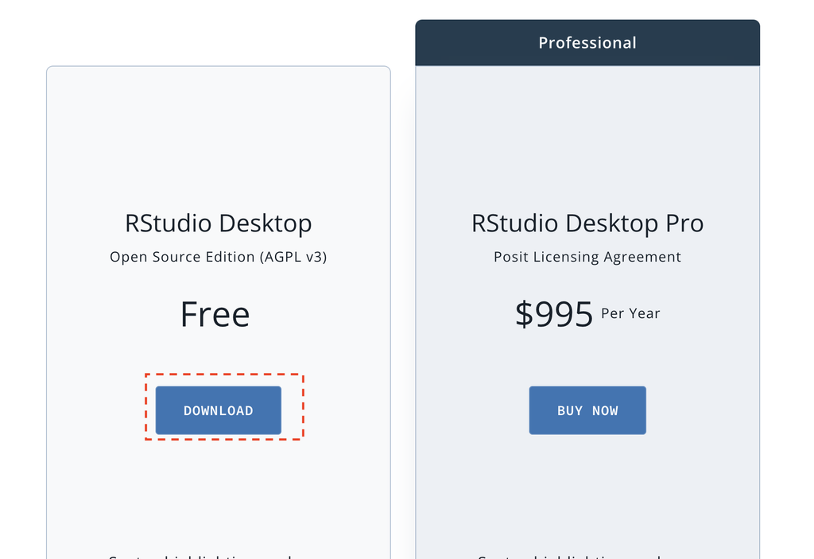

- 移動した先のサイトで下にスクロールして，自分の使っているOSのものをダウンロードしてインストールする（Macはアプリケーションにコピーする）。

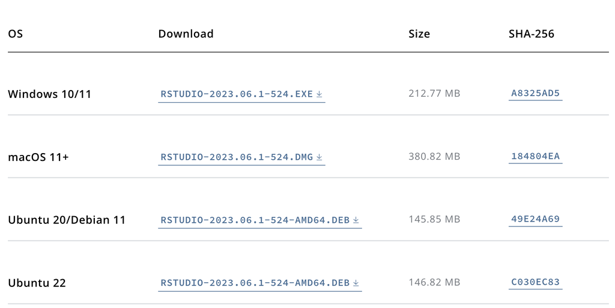

## Rの関数：標準関数

- Rは標準関数で色々な統計解析ができる。
- [Positチートシート](https://posit.co/resources/cheatsheets/?type=translations/#translation-7)の「Base R」（日本語版）を参照したり，「R 使いたい解析名」などでグーグル検索して調べる。
- Rの関数名はわかっているけど，どう使ったらわからない場合，「?関数名」をコンソールにタイプするとヘルプがでてくる。

## Rと関数

- Rを使いこなすには，関数の理解が大切です。以下のように，関数の（）内で，引数を指定すると，左辺に結果が代入されます。

```
戻り値（結果） = 関数（引数（入力））
```

例) 平均値の関数mean()の場合

```
結果 = mean(平均したいデータ)
```

## Rの使い方：CRANパッケージ

- Rでは，標準関数以外にも様々な解析パッケージが作成され，多くは[CRAN](https://cran.r-project.org/)に登録されている。
- CRANにあるパッケージは以下のようにコンソールにタイプするとインストールできます。

```
install.packages("パッケージ名", dependencies = TRUE)
```

- パッケージを使う場合は，以下のようにコンソールにタイプして，呼び出します。

```
library(パッケージ名)
```

## パッケージのインストール

今回の講義で使用するパッケージをインストールする。

```r
install.packages(c('tidyverse','devtools','coin',
                   'gtsummary','effsize','ggdist',
                    'corrr','pwr','psych','car',
                   'lme4','lmerTest','phia',
                   'lavaan','semPlot','GPArotation','meta'))
```

dmetarはgithub経由でインストールする。

```r
devtools::install_github("MathiasHarrer/dmetar")
```

## パッケージや関数の使い方が分からない

- パッケージを探す：「R 解析名」でグーグル検索
- 関数の使い方を探す：（１）「?関数名」をRStudioのコンソールにタイプするとヘルプがでてくるので読む，（２）CRANでパッケージを検索してマニュアルを読む（分かりやすいビネットが公開されていることもある），（３）「関数名 解析名」などでグーグル検索（英語のほうが情報が多そうだがRは日本語でも重要な情報が見つかることも多い）

## パッケージや関数の使い方が分からない

- プログラミングならchatGPTが便利です。

[figure not shown]

## Rはエラーが出て怖い！

[figure not shown]

- エラー内容（赤字）をグーグル検索する or chatGPTに聞いてみる

[figure not shown]

# 再現可能なデータ解析・論文執筆とQuarto

## 再現性の危機

- 心理学研究100本のうち再現されたのは39本 (Open Science Collaboration 2015)
- 引用数が多く効果があるとされた臨床医学研究45本のうち再現されたのは20本 (Ioannidis 2005)
- 1576名の調査から，70%が他の研究者の研究を再現できず，50%が自分の研究の再現もできなかった (Baker 2015)

→研究知見に対する再現可能性の担保が重要！

## ３つの再現可能性

Goodman, Fanelli, and Ioannidis (2016) による３つの再現可能性

1. **方法**の再現可能性: 論文と同じデータに同じ方法を用いて，同じ結果が得られること
2. **結果**の再現可能性: 新規のデータに同じ方法を用いて，同じ結果が得られること
3. **推論**の再現可能性: 結果から質的に同じ結論が得られること

## 方法の再現可能性の問題

- 2000-2014年の生物医学論文441本のうち生データが直接利用可能なのは0本(Iqbal et al. 2016)，2015-2017年の生物医学論文のうちデータの入手可能性を記載したのは18.3%(Wallach, Boyack, and Ioannidis 2018)

→データ共有がなければそもそも不可能・・・

- Science誌掲載論文では，データとコードを共有していた研究が44%，そのうち再現できたのは26%(Stodden, Seiler, and Ma 2018)

→データとコードの共有方法が重要！

## 再現可能性を高めるには

- 生データから最終的な結果までが追跡できるようにコードとドキュメントを用意

[figure not shown]

## Quartoとは

- オープンソースの科学・技術出版システム
- 解析コードと文章を１つのファイル内で統合でき，以下のように文章，コード，結果(プロット)からなるファイルを出力できる。

*平均と標準偏差が１の正規分布から100個の乱数をプロットします。*

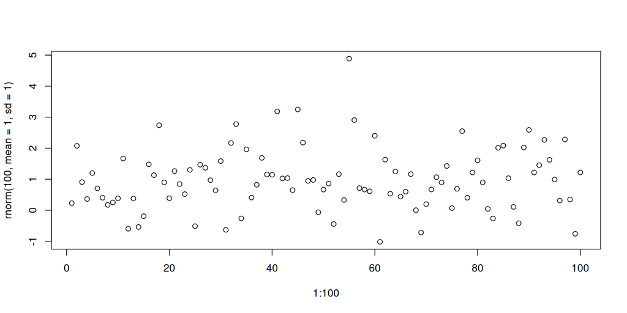

```r
plot(1:100, rnorm(100, mean = 1, sd = 1))
```

## Quartoで生成できるファイル

- Quartoファイルの拡張子はqmd
- Quartoは，qmd形式からMarkdown形式(md)に変換し，それをpandocを介して，HTML，PDF，マイクロソフトWord, マイクロソフトPower Point，ePub形式などに変換できる。


## R Markdownとの違い

- knitrだけでなくJupyterをエンジンに使えるので，PythonやJuliaなどを扱うのが便利になった。
- QuartoはRStudioに限定されず，VS Codeなど他のIDEでも使える。
- R Markdownは用途に合わせて追加パッケージをインストールする形式だが，Quartoは単体で機能できるように作成されている（Rに依存しない）。

→RStudioとR Markdownにかなり慣れているコアユーザーはQuartoに移行する必要はない。むしろ初めて技術・出版システムを使う人向けかもしれない。

## Quartoの使い方

- 一番簡単なのは，**最新**のRとRStudioをインストールする方法（終わり！）
- JupyterエンジンやPython,Juliaは個別にインストールする必要がある（今回のTWSのスコープ外）。

## プロジェクトとディレクトリ構造

- Quartoではデータ解析をするので，別に保存されたデータを読み込む必要がある。
- Quartoのファイルが置かれている場所，データの置かれている場所，Rのカレントワーキングディレクトリの３つが重要になる（qmdファイルからデータが読めないとエラーが出る）。
- RStudioのプロジェクト機能とディレクトリ構造を意識する

## プロジェクトの作成

- 「File」から「New Project…」をクリックする。

[figure not shown]

## New Project Wizard(1)

- まずは「New Directory」をクリックする。
- すでに作成済みのディレクトリをプロジェクトに使う場合は「Existing Directory」，GitHubなどのバージョンコントロールをする場合は「Version Control」を使用する。

[figure not shown]

## New Project Wizard(2)

- 「New Project」をクリックする。
- その他に「R Package」用のプロジェクトなどもある。「Quarto Project」ではプロジェクトフォルダ内にQmdファイルが配置される（今回は使わない）。

[figure not shown]

## New Project Wizard(3)

- Directory nameにプロジェクト名を書き込む（sotsuronとかでいいので，分かるように英語・ローマ字で書く）。
- Create project as subdirectory of :でディレクトリの場所を決める（指定した場所に上記のDirectory nameのディレクトリが作成される）。

[figure not shown]

## プロジェクトの利用

- プロジェクトを開くと，右下パネルのFilesが指定したディレクトリになる。
- ディレクトリ内にRprojという拡張子のファイルが作成される（プロジェクトの情報を保存したファイル）。
- プロジェクトのディレクトリがカレントワーキングディレクトリになる(Consoleで以下を実行すると確認できる)。このディレクトリを起点に，Qmdファイルを作成したり，データを配置する。

```r
getwd()
```

## Recent Projects使用のススメ

- 研究や作業単位ごとにProjectを作る。その際にProject間の切り替えをするのにRecent Projectsが便利。
- Recent Projectsには，過去に開いたプロジェクトが出てくるので，使うものを選択すれば良い。

[figure not shown]

## ディレクトリを組織化

- 左のようになっているとまずい。

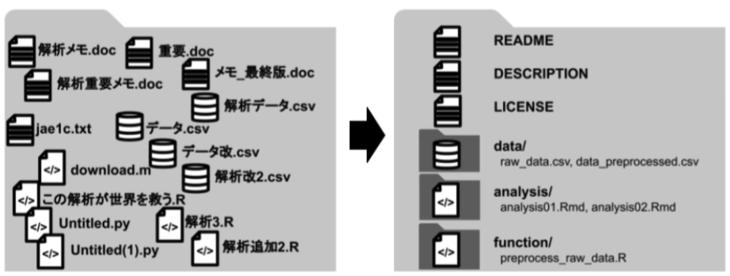

- 中身が分かるようにファイル名をつけ，解析，データ，関数などでフォルダにまとめる(Research compendium)。

## 今回のTWSのディレクトリ構成

- 今回のTWSでは最小のディレクトリ構成にする。
- プロジェクトのディレクトリ直下にanalysis01.qmdファイルを置く（解析を分ける必要ができたらanalysis02.qmdと連番をふる）
- データはdataフォルダを作成して，そのフォルダ内に配置する。

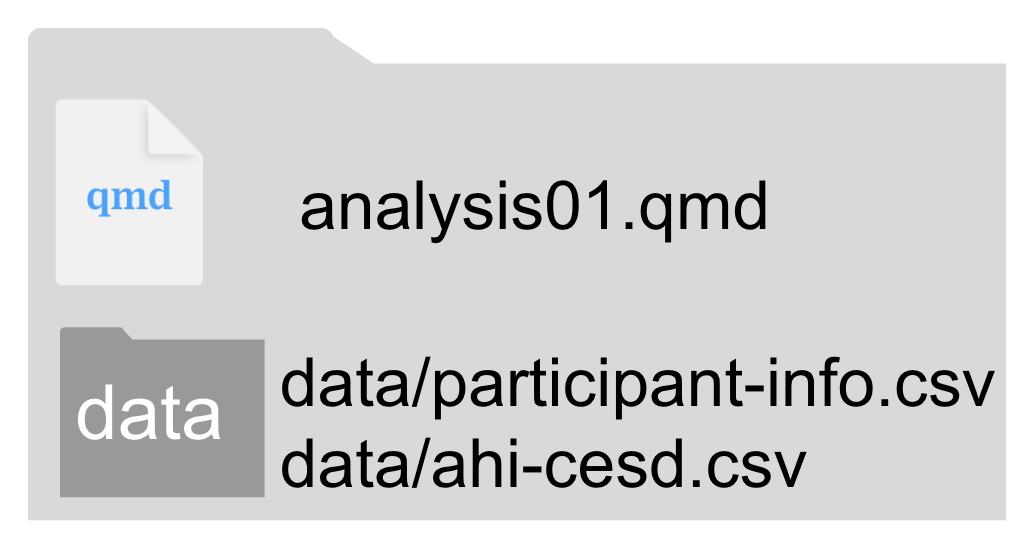

# Quartoを使った解析報告方法

## Qmdファイルの作成(1)

- 新規作成ボタンをクリックして(1)，「Quarto Document…」をクリックして(2)，Qmdファイルを作成。

[figure not shown]

## Qmdファイルの作成(2)

- TitleとAuthorを記入して，「Create」をクリックする(TitleとAuthorは変更可能なので，適当で良い)。

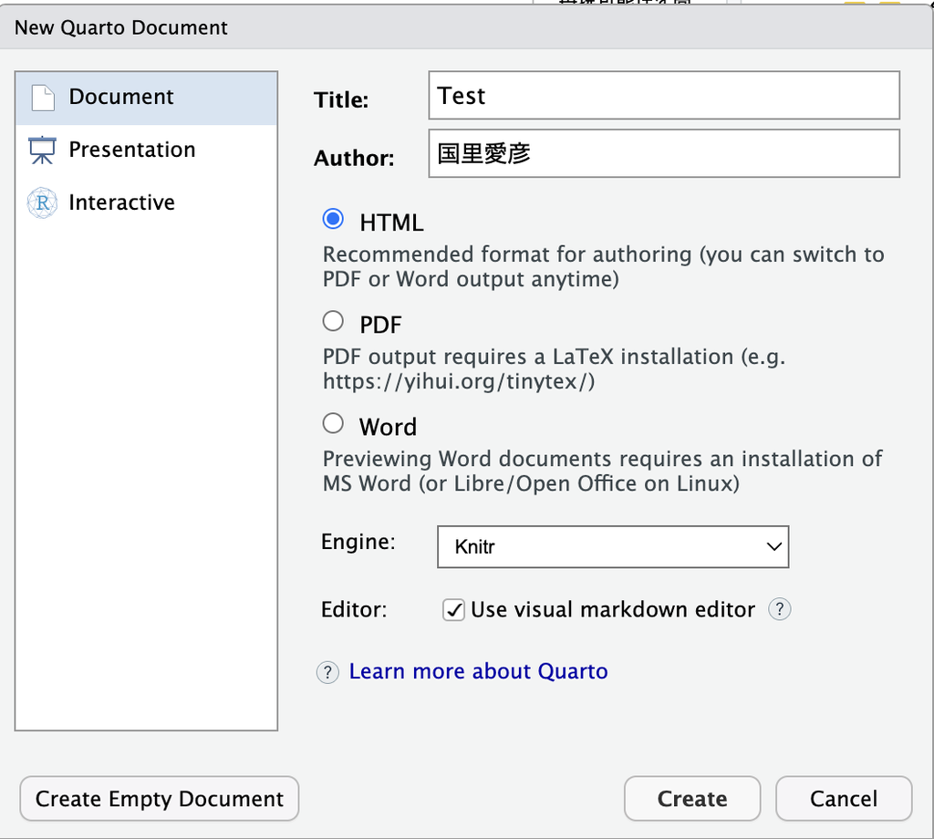

## Quarto用語説明：YAML

- qmdファイルを作ると”—“で囲われた箇所があり，これはドキュメントのメタデータの情報になる（今回の場合は，htmlファイル形式で出力をするなど）。必要に応じて変更を加えることになる。

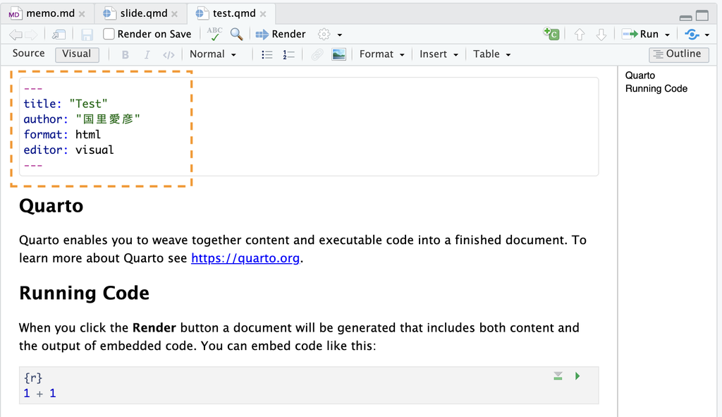

## Quarto用語説明：Visual editor

- QuartoはMarkdown形式で文章やコードブックが書けるが，いきなりMarkdownとか言われても困ると思う。
- Visual editorモードなら，Wordのような感じで，太字，斜体などの指定や挿入を上のツールバーから実施できる。

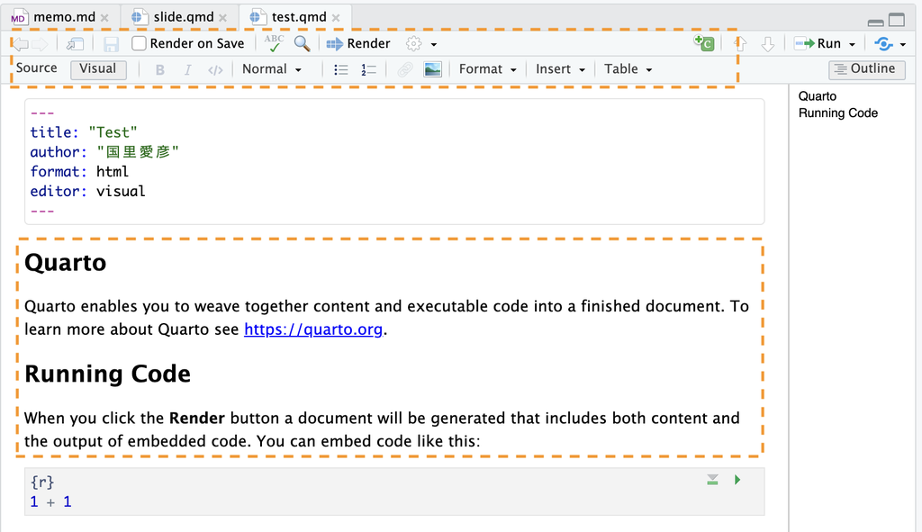

## Quarto用語説明：Outline

- RStudioは文章の見出し設定に合わせて，右にアウトラインを示してくれる。

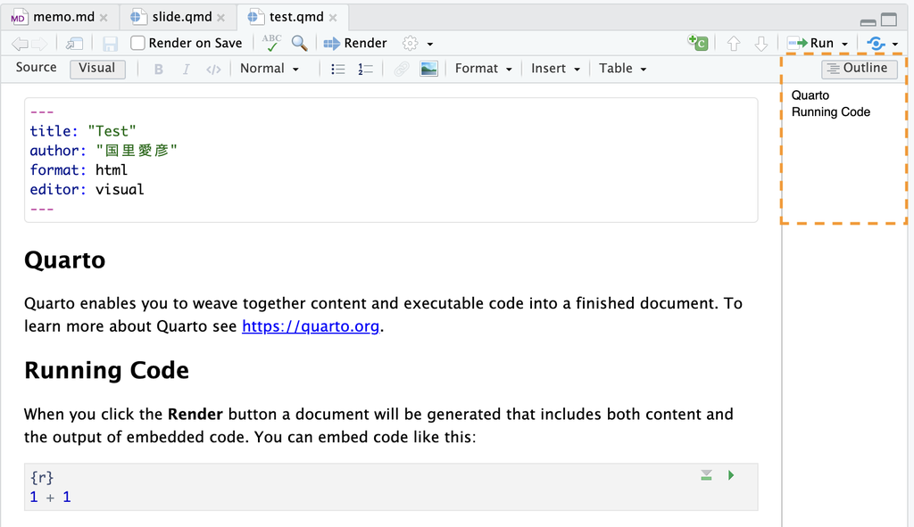